# Model Selection

# Best Subset Selection

We apply the best subset selection to the `Hitters` data. We wish to predict a baseball player’s `Salary` on the basis of various statistics associated with performance in the previous year.

First of all, we note that `Salary` variable is missing for some of the players. The `is.na()` function can be used to identify the missing observations. It returns a vector of the same length as the input vector, with a `TRUE` for any elements that are missing, and a `FALSE` for non-missing elements. The `sum()` function can then be used to count all of the missing elements.

```r
library(ISLR2)
```

Let’s have a look at the variable names:

```r
names(Hitters)
```

```
##  [1] "AtBat"     "Hits"      "HmRun"     "Runs"      "RBI"       "Walks"
##  [7] "Years"     "CAtBat"    "CHits"     "CHmRun"    "CRuns"     "CRBI"
## [13] "CWalks"    "League"    "Division"  "PutOuts"   "Assists"   "Errors"
## [19] "Salary"    "NewLeague"
```

We can also view the dataset dimensions:

```r
dim(Hitters)
```

```
## [1] 322  20
```

Finally, let’s identify any missing data:

```r
sum(is.na(Hitters$Salary))
```

```
## [1] 59
```

We can see that `Salary` is missing for `59` players. The `na.omit()` function removes all of the rows that have missing values in any variable.

```r
hitters <- na.omit(Hitters)
sum(is.na(hitters))
```

```
## [1] 0
```

We now have no `NA` values.

The `regsubsets()` function (part of the `leaps` library) performs best subset selection by identifying the best model that contains a given number of predictors, where *best* is quantified using RSS. The syntax is the same as for `lm()`. The `summary()` command outputs the best set of variables for each model size.

```r
library(leaps)
regfit_full <- regsubsets(Salary ~ ., hitters)
summary(regfit_full)
```

```
## Subset selection object
## Call: regsubsets.formula(Salary ~ ., hitters)
## 19 Variables  (and intercept)
##            Forced in Forced out
## AtBat          FALSE      FALSE
## Hits           FALSE      FALSE
## HmRun          FALSE      FALSE
## Runs           FALSE      FALSE
## RBI            FALSE      FALSE
## Walks          FALSE      FALSE
## Years          FALSE      FALSE
## CAtBat         FALSE      FALSE
## CHits          FALSE      FALSE
## CHmRun         FALSE      FALSE
## CRuns          FALSE      FALSE
## CRBI           FALSE      FALSE
## CWalks         FALSE      FALSE
## LeagueN        FALSE      FALSE
## DivisionW      FALSE      FALSE
## PutOuts        FALSE      FALSE
## Assists        FALSE      FALSE
## Errors         FALSE      FALSE
## NewLeagueN     FALSE      FALSE
## 1 subsets of each size up to 8
## Selection Algorithm: exhaustive
##          AtBat Hits HmRun Runs RBI Walks Years CAtBat CHits CHmRun CRuns CRBI
## 1  ( 1 ) " "   " "  " "   " "  " " " "   " "   " "    " "   " "    " "   "*"
## 2  ( 1 ) " "   "*"  " "   " "  " " " "   " "   " "    " "   " "    " "   "*"
## 3  ( 1 ) " "   "*"  " "   " "  " " " "   " "   " "    " "   " "    " "   "*"
## 4  ( 1 ) " "   "*"  " "   " "  " " " "   " "   " "    " "   " "    " "   "*"
## 5  ( 1 ) "*"   "*"  " "   " "  " " " "   " "   " "    " "   " "    " "   "*"
## 6  ( 1 ) "*"   "*"  " "   " "  " " "*"   " "   " "    " "   " "    " "   "*"
## 7  ( 1 ) " "   "*"  " "   " "  " " "*"   " "   "*"    "*"   "*"    " "   " "
## 8  ( 1 ) "*"   "*"  " "   " "  " " "*"   " "   " "    " "   "*"    "*"   " "
##          CWalks LeagueN DivisionW PutOuts Assists Errors NewLeagueN
## 1  ( 1 ) " "    " "     " "       " "     " "     " "    " "
## 2  ( 1 ) " "    " "     " "       " "     " "     " "    " "
## 3  ( 1 ) " "    " "     " "       "*"     " "     " "    " "
## 4  ( 1 ) " "    " "     "*"       "*"     " "     " "    " "
## 5  ( 1 ) " "    " "     "*"       "*"     " "     " "    " "
## 6  ( 1 ) " "    " "     "*"       "*"     " "     " "    " "
## 7  ( 1 ) " "    " "     "*"       "*"     " "     " "    " "
## 8  ( 1 ) "*"    " "     "*"       "*"     " "     " "    " "
```

An asterisk indicates that a given variable is included in the corresponding model. For instance, this output indicates that the best two-variable model contains only `Hits` and `CRBI`. By default, `regsubsets()` only reports results up to the best eight-variable model. But the `nvmax` argument can be used in order to return as many variables as are desired. Herem we fit up to a 19-variable model.

```r
regfit_full <- regsubsets(Salary ~ ., data = hitters, nvmax = 19)
regfit_sum <- summary(regfit_full)
```

The `summary()` function also returns *R2*, RSS, adjusted *R2*, *Cp*, and BIC. We can examine these to try and select the *best* overall model.

For instance, we can see that the *R2* statistic increases from 32% when only one variable in included in the model, to almost 55% when all variables are included. As expected, the *R2* statistic increases monotonically as more variables are included.

```r
regfit_sum$rsq
```

```
##  [1] 0.3214501 0.4252237 0.4514294 0.4754067 0.4908036 0.5087146 0.5141227
##  [8] 0.5285569 0.5346124 0.5404950 0.5426153 0.5436302 0.5444570 0.5452164
## [15] 0.5454692 0.5457656 0.5459518 0.5460945 0.5461159
```

Plotting RSS, adjusted *R2*, *Cp*, and BIC for all of the models at once will help us decide which model to select. Note the `type = l` option tells `R` to connect the plotted points with lines.

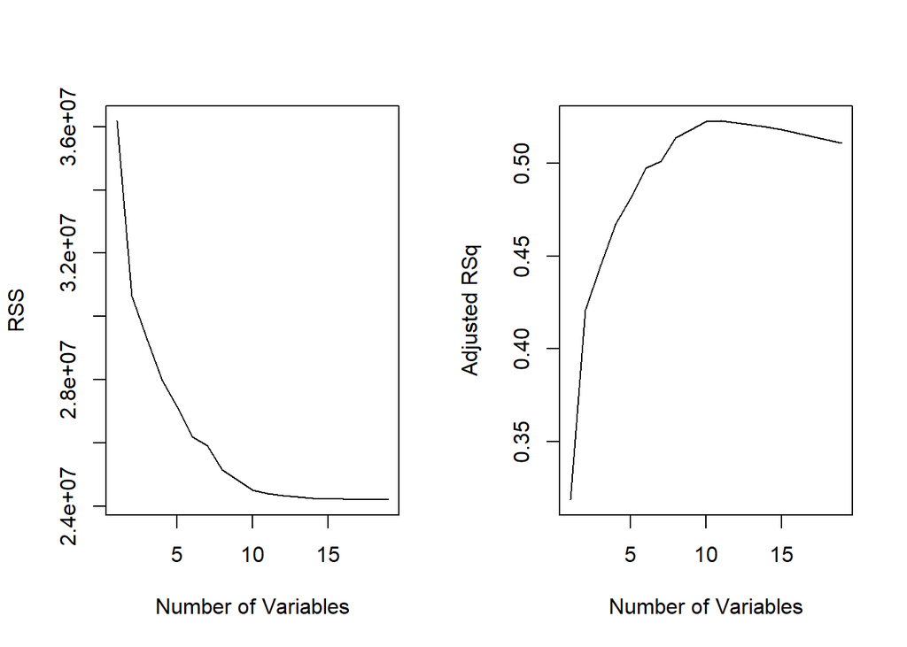

```r
par(mfrow = c(1, 2))
plot(regfit_sum$rss, xlab = "Number of Variables",
    ylab = "RSS", type = "l")
plot(regfit_sum$adjr2, xlab = "Number of Variables",
    ylab = "Adjusted RSq", type = "l")
```

The `points()` command works like the `plot()` command, except that it puts points on a plot that has already been created, instead of creating a new plot. The `which.max()` function can be used to identify the location of the maximum point of a vector. We will now plot a red dot to indicate the model with the largest adjusted *R2* statistic

```r
which.max(regfit_sum$adjr2)
```

```
## [1] 11
```

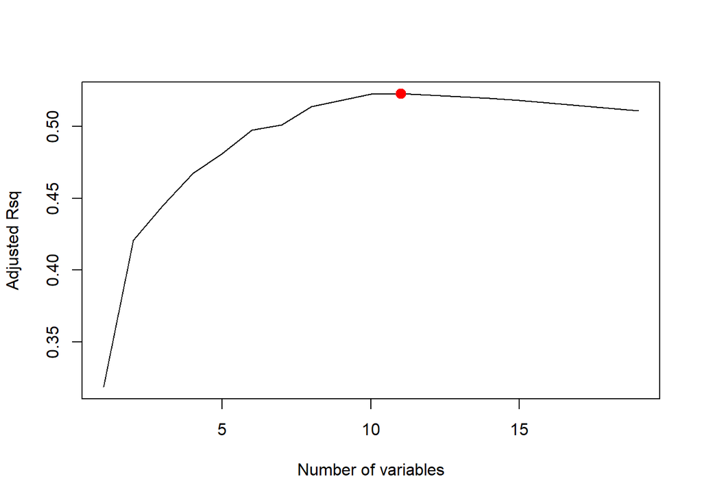

```r
plot(regfit_sum$adjr2, xlab = "Number of variables",
    ylab = "Adjusted Rsq", type = "l")
points(11, regfit_sum$adjr2[11], col = "red", cex = 2,
    pch = 20)
```

In a similar fashion, we can plot for Cp and BIC statistics, and indicate the models with the smallest statistic using `which.min()`.

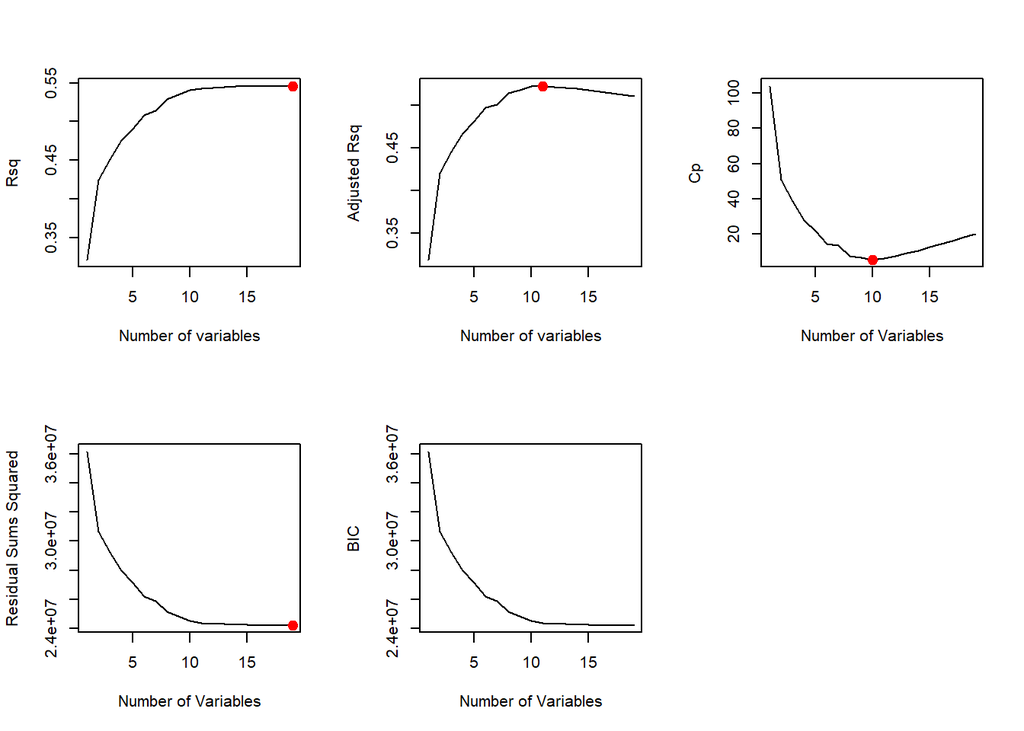

```r
par(mfrow = c(2, 3))
plot(regfit_sum$rsq, xlab = "Number of variables",
    ylab = "Rsq", type = "l")
points(which.max(regfit_sum$rsq), regfit_sum$rsq[which.max(regfit_sum$rsq)],
    col = "red", cex = 2, pch = 20)
plot(regfit_sum$adjr2, xlab = "Number of variables",
    ylab = "Adjusted Rsq", type = "l")
points(which.max(regfit_sum$adjr2),
    regfit_sum$adjr2[which.max(regfit_sum$adjr2)],
    col = "red", cex = 2, pch = 20)
plot(regfit_sum$cp, xlab = "Number of Variables",
    ylab = "Cp", type = "l")
points(which.min(regfit_sum$cp), regfit_sum$cp[which.min(regfit_sum$cp)],
    col = "red", cex = 2, pch = 20)
plot(regfit_sum$rss, xlab = "Number of Variables",
    ylab = "Residual Sums Squared", type = "l")
points(which.min(regfit_sum$rss), regfit_sum$rss[which.min(regfit_sum$rss)],
    col = "red", cex = 2, pch = 20)
plot(regfit_sum$rss, xlab = "Number of Variables",
    ylab = "BIC", type = "l")
points(which.min(regfit_sum$bic), regfit_sum$bic[which.min(regfit_sum$bic)],
    col = "red", cex = 2, pch = 20)
```

The `regsubsets()` function has a built in `plot()` command which can be used to dispaly the selected variables for the best model with a given number of predictors.

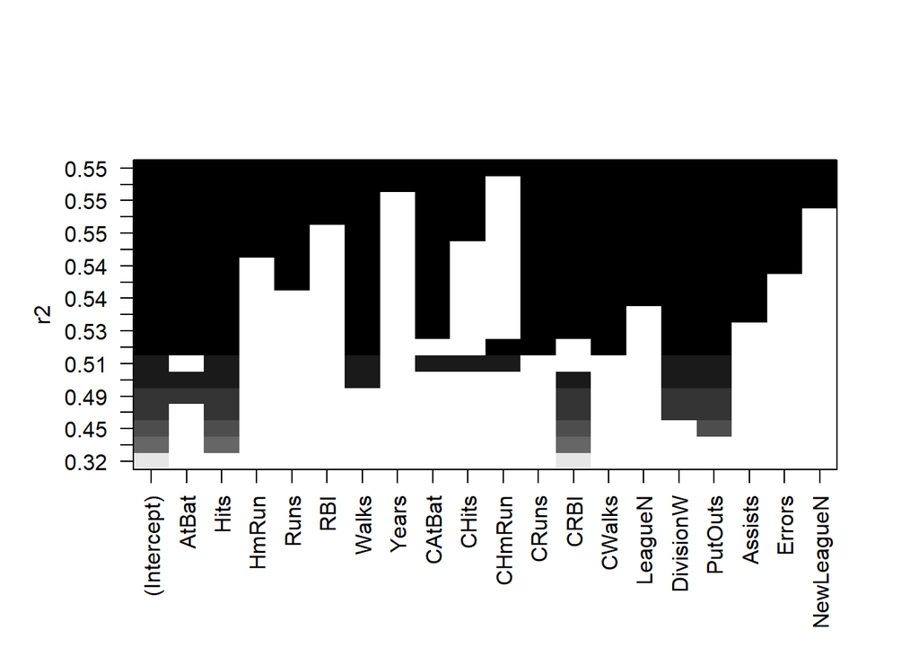

```r
plot(regfit_full, scale = "r2")
```

```r
coef(regfit_full, 6)
```

```
##  (Intercept)        AtBat         Hits        Walks         CRBI    DivisionW
##   91.5117981   -1.8685892    7.6043976    3.6976468    0.6430169 -122.9515338
##      PutOuts
##    0.2643076
```

# Forwards and Backwards Stepwise Selection

We can also use the `regsubsets()` function to perform forward or backwise stepwise selection, using the argument `method = "forward` or `method = "backward"`.

```r
regfit_fwd <- regsubsets(Salary ~ ., data = hitters,
    nvmax = 19, method = "forward")
summary(regfit_fwd)
```

```
## Subset selection object
## Call: regsubsets.formula(Salary ~ ., data = hitters, nvmax = 19, method = "forward")
## 19 Variables  (and intercept)
##            Forced in Forced out
## AtBat          FALSE      FALSE
## Hits           FALSE      FALSE
## HmRun          FALSE      FALSE
## Runs           FALSE      FALSE
## RBI            FALSE      FALSE
## Walks          FALSE      FALSE
## Years          FALSE      FALSE
## CAtBat         FALSE      FALSE
## CHits          FALSE      FALSE
## CHmRun         FALSE      FALSE
## CRuns          FALSE      FALSE
## CRBI           FALSE      FALSE
## CWalks         FALSE      FALSE
## LeagueN        FALSE      FALSE
## DivisionW      FALSE      FALSE
## PutOuts        FALSE      FALSE
## Assists        FALSE      FALSE
## Errors         FALSE      FALSE
## NewLeagueN     FALSE      FALSE
## 1 subsets of each size up to 19
## Selection Algorithm: forward
##           AtBat Hits HmRun Runs RBI Walks Years CAtBat CHits CHmRun CRuns CRBI
## 1  ( 1 )  " "   " "  " "   " "  " " " "   " "   " "    " "   " "    " "   "*"
## 2  ( 1 )  " "   "*"  " "   " "  " " " "   " "   " "    " "   " "    " "   "*"
## 3  ( 1 )  " "   "*"  " "   " "  " " " "   " "   " "    " "   " "    " "   "*"
## 4  ( 1 )  " "   "*"  " "   " "  " " " "   " "   " "    " "   " "    " "   "*"
## 5  ( 1 )  "*"   "*"  " "   " "  " " " "   " "   " "    " "   " "    " "   "*"
## 6  ( 1 )  "*"   "*"  " "   " "  " " "*"   " "   " "    " "   " "    " "   "*"
## 7  ( 1 )  "*"   "*"  " "   " "  " " "*"   " "   " "    " "   " "    " "   "*"
## 8  ( 1 )  "*"   "*"  " "   " "  " " "*"   " "   " "    " "   " "    "*"   "*"
## 9  ( 1 )  "*"   "*"  " "   " "  " " "*"   " "   "*"    " "   " "    "*"   "*"
## 10  ( 1 ) "*"   "*"  " "   " "  " " "*"   " "   "*"    " "   " "    "*"   "*"
## 11  ( 1 ) "*"   "*"  " "   " "  " " "*"   " "   "*"    " "   " "    "*"   "*"
## 12  ( 1 ) "*"   "*"  " "   "*"  " " "*"   " "   "*"    " "   " "    "*"   "*"
## 13  ( 1 ) "*"   "*"  " "   "*"  " " "*"   " "   "*"    " "   " "    "*"   "*"
## 14  ( 1 ) "*"   "*"  "*"   "*"  " " "*"   " "   "*"    " "   " "    "*"   "*"
```

[output cut: 10 more lines]

```
## 5  ( 1 )  " "    " "     "*"       "*"     " "     " "    " "
## 6  ( 1 )  " "    " "     "*"       "*"     " "     " "    " "
## 7  ( 1 )  "*"    " "     "*"       "*"     " "     " "    " "
## 8  ( 1 )  "*"    " "     "*"       "*"     " "     " "    " "
## 9  ( 1 )  "*"    " "     "*"       "*"     " "     " "    " "
## 10  ( 1 ) "*"    " "     "*"       "*"     "*"     " "    " "
## 11  ( 1 ) "*"    "*"     "*"       "*"     "*"     " "    " "
## 12  ( 1 ) "*"    "*"     "*"       "*"     "*"     " "    " "
## 13  ( 1 ) "*"    "*"     "*"       "*"     "*"     "*"    " "
## 14  ( 1 ) "*"    "*"     "*"       "*"     "*"     "*"    " "
## 15  ( 1 ) "*"    "*"     "*"       "*"     "*"     "*"    " "
## 16  ( 1 ) "*"    "*"     "*"       "*"     "*"     "*"    " "
## 17  ( 1 ) "*"    "*"     "*"       "*"     "*"     "*"    "*"
## 18  ( 1 ) "*"    "*"     "*"       "*"     "*"     "*"    "*"
## 19  ( 1 ) "*"    "*"     "*"       "*"     "*"     "*"    "*"
```

```r
regfit_bwd <- regsubsets(Salary ~ ., data = hitters,
    nvmax = 19, method = "backward")
summary(regfit_bwd)
```

```
## Subset selection object
## Call: regsubsets.formula(Salary ~ ., data = hitters, nvmax = 19, method = "backward")
## 19 Variables  (and intercept)
##            Forced in Forced out
## AtBat          FALSE      FALSE
## Hits           FALSE      FALSE
## HmRun          FALSE      FALSE
## Runs           FALSE      FALSE
## RBI            FALSE      FALSE
## Walks          FALSE      FALSE
## Years          FALSE      FALSE
## CAtBat         FALSE      FALSE
## CHits          FALSE      FALSE
## CHmRun         FALSE      FALSE
## CRuns          FALSE      FALSE
## CRBI           FALSE      FALSE
## CWalks         FALSE      FALSE
## LeagueN        FALSE      FALSE
## DivisionW      FALSE      FALSE
## PutOuts        FALSE      FALSE
## Assists        FALSE      FALSE
## Errors         FALSE      FALSE
## NewLeagueN     FALSE      FALSE
## 1 subsets of each size up to 19
## Selection Algorithm: backward
##           AtBat Hits HmRun Runs RBI Walks Years CAtBat CHits CHmRun CRuns CRBI
## 1  ( 1 )  " "   " "  " "   " "  " " " "   " "   " "    " "   " "    "*"   " "
## 2  ( 1 )  " "   "*"  " "   " "  " " " "   " "   " "    " "   " "    "*"   " "
## 3  ( 1 )  " "   "*"  " "   " "  " " " "   " "   " "    " "   " "    "*"   " "
## 4  ( 1 )  "*"   "*"  " "   " "  " " " "   " "   " "    " "   " "    "*"   " "
## 5  ( 1 )  "*"   "*"  " "   " "  " " "*"   " "   " "    " "   " "    "*"   " "
## 6  ( 1 )  "*"   "*"  " "   " "  " " "*"   " "   " "    " "   " "    "*"   " "
## 7  ( 1 )  "*"   "*"  " "   " "  " " "*"   " "   " "    " "   " "    "*"   " "
## 8  ( 1 )  "*"   "*"  " "   " "  " " "*"   " "   " "    " "   " "    "*"   "*"
## 9  ( 1 )  "*"   "*"  " "   " "  " " "*"   " "   "*"    " "   " "    "*"   "*"
## 10  ( 1 ) "*"   "*"  " "   " "  " " "*"   " "   "*"    " "   " "    "*"   "*"
## 11  ( 1 ) "*"   "*"  " "   " "  " " "*"   " "   "*"    " "   " "    "*"   "*"
## 12  ( 1 ) "*"   "*"  " "   "*"  " " "*"   " "   "*"    " "   " "    "*"   "*"
## 13  ( 1 ) "*"   "*"  " "   "*"  " " "*"   " "   "*"    " "   " "    "*"   "*"
## 14  ( 1 ) "*"   "*"  "*"   "*"  " " "*"   " "   "*"    " "   " "    "*"   "*"
```

[output cut: 10 more lines]

```
## 5  ( 1 )  " "    " "     " "       "*"     " "     " "    " "
## 6  ( 1 )  " "    " "     "*"       "*"     " "     " "    " "
## 7  ( 1 )  "*"    " "     "*"       "*"     " "     " "    " "
## 8  ( 1 )  "*"    " "     "*"       "*"     " "     " "    " "
## 9  ( 1 )  "*"    " "     "*"       "*"     " "     " "    " "
## 10  ( 1 ) "*"    " "     "*"       "*"     "*"     " "    " "
## 11  ( 1 ) "*"    "*"     "*"       "*"     "*"     " "    " "
## 12  ( 1 ) "*"    "*"     "*"       "*"     "*"     " "    " "
## 13  ( 1 ) "*"    "*"     "*"       "*"     "*"     "*"    " "
## 14  ( 1 ) "*"    "*"     "*"       "*"     "*"     "*"    " "
## 15  ( 1 ) "*"    "*"     "*"       "*"     "*"     "*"    " "
## 16  ( 1 ) "*"    "*"     "*"       "*"     "*"     "*"    " "
## 17  ( 1 ) "*"    "*"     "*"       "*"     "*"     "*"    "*"
## 18  ( 1 ) "*"    "*"     "*"       "*"     "*"     "*"    "*"
## 19  ( 1 ) "*"    "*"     "*"       "*"     "*"     "*"    "*"
```

For instance, we see that using forward stepwise selection tells us the best one-variable model contains only “CRBI”, and the best two-variable model additionally includes `Hits`. The best seven-variable models identified by forward and backwards selection differ.

# Choosing Among Models Using the Validation-Set Approach and Cross-Validation

We previously saw that it is possible to choose among a set of models of different sizes using different criterions. We will now consider how to do this using the validation set and cross-validation approaches.

In order for these approaches to yield accurate estimates of the test error, we must use only the training observations to perform all aspects of model-fitting - including variable selection. Therefore, the determination of which model of a given size is best must be made using *only the training observations*. The point is subtle but important. If the full data set is used to perform the best subset selection step, the validation set errors and cross-validation errors that we obtain will not be accurate estimates of the test error.

In order to use the validation set approach, we begin by splitting the observations into a training set and a test set. We do this by creating a random vector, `train` of elementents equal to `TRUE` if the corresponding observation is in the training set, and `FALSE` otherwise. The vector `test` has a `TRUE` if the observation is in the test set, and a `FALSE` otherwise. Note the `!` in the command to create `test` causes the true and false to be switched around. We also set a random seed so that the user will obtain the same training set split.

```r
set.seed(42)
train <- sample(c(TRUE, FALSE), nrow(hitters), replace = TRUE)
test <- (!train)
```

Now, we apply `regsubsets()` to the training set in order to perform best subset selection.

```r
regfit_best <- regsubsets(Salary ~ ., data = hitters[train, ], nvmax = 19)
```

Notice that we subset the `hitters` data frame directly in the call in order to access only the training subset of the data, using the expression `hitters[train, ]`. We now compute the validation set error for the best model of each model size. We first make a model matrix from the test data.

```r
test_mat <- model.matrix(Salary ~ ., data = hitters[test, ])
```

```r
val_err <- rep(NA, 19)
for (i in 1:19) {
    coefi <- coef(regfit_best, id = i)
    pred <- test_mat[, names(coefi)] %*% coefi
    val_err[i] <- mean((hitters$Salary[test] - pred)^2)
}
```

We find that the best model is the one that contains five variables.

```r
which.min(val_err)
```

```
## [1] 5
```

```r
coef(regfit_best, 5)
```

```
## (Intercept)       Walks      CAtBat       CHits      CHmRun     PutOuts
## 102.0163457   3.7019974  -0.4002084   1.5041824   2.9007854   0.1975283
```

This was a bit tedious, partly becuase there is no `predict()` method for `regsubsets()`. Since we will be using this function again, we can capture our steps above and write our own predict method.

```r
predict.regsubsets <- function(object, newdata, id, ...) {
    form <- as.formula(object$call[[2]])
    mat <- model.matrix(form, newdata)
    coefi <- coef(object, id = id)
    xvars <- names(coefi)
    mat[, xvars] %*% coefi
}
```

Our function pretty much mimics what we did above. The only complex part is how we extracted the formula used in the call to `regsubsets()`. We demonstrate how we use this function below, when we do cross-validation.

```r
regfit_best <- regsubsets(Salary ~ ., data = hitters, nvmax = 19)
coef(regfit_best, 5)
```

```
##  (Intercept)        AtBat         Hits         CRBI    DivisionW      PutOuts
##   97.7684116   -1.4401428    7.1753197    0.6882079 -129.7319386    0.2905164
```

We now try to choose among the models of different sizes using cross-validation. This approach is somewhat involved, as we must perform best subset selection *within each of the K training sets*. Despite this, we see that with its clever subsetting syntax, `R` makes this job quite easy. First, we create a vector that allocates each observation to one of *k = 10* folds, and we create a matrix in which we store the results.

```r
k <- 10
n <- nrow(hitters)
set.seed(42)
folds <- sample(rep(1:k, length = n))
cv_errors <- matrix(NA, k, 19,
    dimnames = list(NULL, paste(1:19)))
```

Now, we write a loop that performs cross-validation. In the *j*th fold, the elements of `folds` that equal *`j`* are in the test set, and the remainder are in the training set. We make our predictions for each model suze (using our new `predict()` method), compute the test errors on the appropriate subset, and store them in the appropriate slot in the matrix `cv_errors`. Note that in the following code, `R` will automatically use our `predict.regsubsets()` function when we call `predict()` because the `best_fit` object has class `regsubsets`.

```r
for (j in 1:k) {
    best_fit <- regsubsets(Salary ~ ., data = hitters[folds != j, ],
        nvmax = 19)
    for (i in 1:19) {
        pred <- predict(best_fit, hitters[folds == j, ], id = i)
        cv_errors[j, i] <-
            mean((hitters$Salary[folds == j] - pred)^2)
    }
}
```

```r
dim(cv_errors)
```

```
## [1] 10 19
```

This has given us a 10 x 19 matrix of which the *(j,i)* element corresponds to the test MSE for the *j*th cross-validation fold for the best *i*-variable model. We use the `apply()` function to average over the columns of this matrix in order to obtain a vector for which the *i*th element is the cross-validation error for the *i*-variable model.

```r
mean_cv_err <- apply(cv_errors, 2, mean)
mean_cv_err
```

```
##        1        2        3        4        5        6        7        8
## 148792.2 133409.7 128815.4 133643.2 132241.4 124607.0 124436.0 116161.1
##        9       10       11       12       13       14       15       16
## 113338.7 115763.9 117847.1 115752.1 116821.3 116151.9 116561.1 117471.9
##       17       18       19
## 118130.7 118916.7 118836.9
```

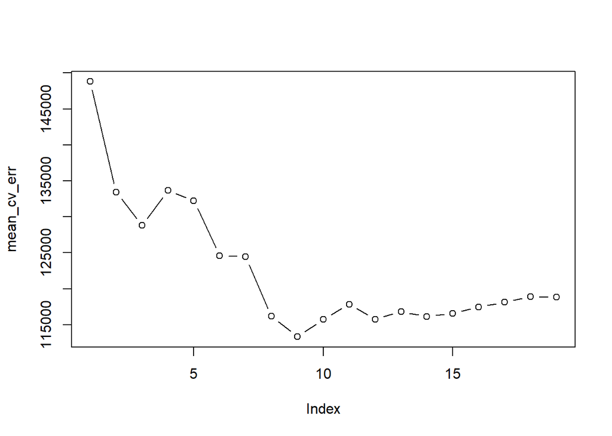

```r
par(mfrow = c(1, 1))
plot(mean_cv_err, type = "b")
```

```r
reg_best <- regsubsets(Salary ~ ., data = hitters, nvmax = 19)
coef(reg_best, 10)
```

```
##  (Intercept)        AtBat         Hits        Walks       CAtBat        CRuns
##  162.5354420   -2.1686501    6.9180175    5.7732246   -0.1300798    1.4082490
##         CRBI       CWalks    DivisionW      PutOuts      Assists
##    0.7743122   -0.8308264 -112.3800575    0.2973726    0.2831680
```